# SI 618: Data Manipulation and Analysis

## 05 - Data analysis II: ANOVA, t-test, linear models

### Dr. Chris Teplovs, School of Information, University of Michigan

This work is licensed under a [Creative Commons Attribution-NonCommercial-ShareAlike 4.0 International License](http://creativecommons.org/licenses/by-nc-sa/4.0/).

## Visualization for Data Scientists

We're going to ask a special virtual guest lecturer to provide some background on data visualization. Together, we'll watch [a brief (8-minute video) by Dr. Chris Brooks](https://www.coursera.org/learn/python-plotting/lecture/qrqqa/tools-for-thinking-about-design-alberto-cairo) and pause it several times to answer the following questions:

## Q1a: As someone who is studying data science, who are you trying to reach through your visualizations?

(replace this with your response) I might try to reach people who are not specialized in the problem I am presenting or analyzing. Visualizations could be use to effectively convey the key information for people who are not well familier with the given topics or doesn't know much about data science.

## Q1b: What sense can you make of this image?

[figure not shown]

1. The higher percentage of chapters accessed, the higher adjusted grade tend to occur.
2. From the blue dots could tell the general amount of sample in dataset.
3. The red cross might indicate the median or mean or something else.

## Q1c: How many different kinds of information can you see in the Minard graphic, and what are they?

[figure not shown]

The temperature of different places; Name of cities; Number of troops in different places

## Returning to Seaborn:

https://seaborn.pydata.org/examples/index.html

Take a look at the different visualizations that are possible.

## Q2a: Provide the title, description, and URL of one of the visualizations that you find particularly interesting and explain why you find it interesting.

Hexbin plot with marginal distributions

The combination of historgrams on two dimension and a graph of hexagons with different colors indicating the dense of data

https://seaborn.pydata.org/examples/hexbin_marginals.html

## Q2b: Given what we learned from Prof. Brooks, indicate 1-3 axes from Cairo's Visual Wheel where your chosen Seaborn visualization would likely score highly. Explain why.

[figure not shown]

The Hexbin might be scored highly in Abstraction, Familiarity and Multidimensionality. The use of hexagons is abstractive, the size might indicates the extend of data variance, the color indicates the density. For the familiarity, it is not a brand new representation.

## Seaborn versus Matplotlib

- Matplotlib
  - Low-level, basis for many packages
  - Painful to construct certain graphs
  - Not Pandas friendly
  - Not interactive
- Seaborn
  - Pandas friendlier
  - Great for some stats plots

## Part 1: Iris dataset

[figure not shown]

```python
import seaborn as sns
```

```python
df = sns.load_dataset('iris')
df.head()
```

|  | sepal_length | sepal_width | petal_length | petal_width | species |
| --- | --- | --- | --- | --- | --- |
| 0 | 5.1 | 3.5 | 1.4 | 0.2 | setosa |
| 1 | 4.9 | 3.0 | 1.4 | 0.2 | setosa |
| 2 | 4.7 | 3.2 | 1.3 | 0.2 | setosa |
| 3 | 4.6 | 3.1 | 1.5 | 0.2 | setosa |
| 4 | 5.0 | 3.6 | 1.4 | 0.2 | setosa |

Remember our distplots:

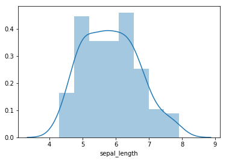

```python
sns.distplot(df.sepal_length)
```

## Q3: Create similar plots for the other three numeric variables in the dataset. In a couple of sentences, describe each of the plots.

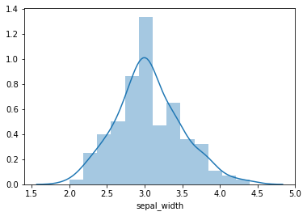

```python
# insert your code here
sns.distplot(df.sepal_width)
```

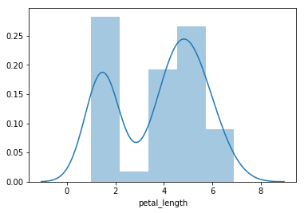

```python
sns.distplot(df.petal_length)
```

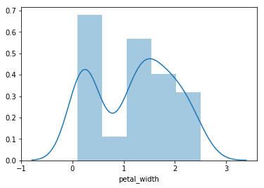

```python
sns.distplot(df.petal_width)
```

We often want to see how variables vary with each other. We'll get into the details in a few classes, but for now let's examine them visually. In seaborn, we do this using the jointplot(). So, for example, if we wanted to look at the relationship between the distributions of sepal_length and sepal_width, we could do something like:

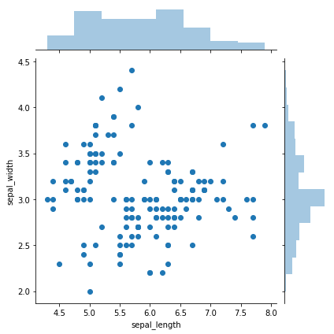

```python
sns.jointplot(x='sepal_length',y='sepal_width',data=df)
```

## Q4: It's a bit difficult to see where the interesting areas in the plot are, so it's worth trying a hexbin plot. Go ahead and copy the above code block and add ```kind="hex"``` to the jointplot parameters. In a couple of sentences, describe what stands out to you about the visualization.

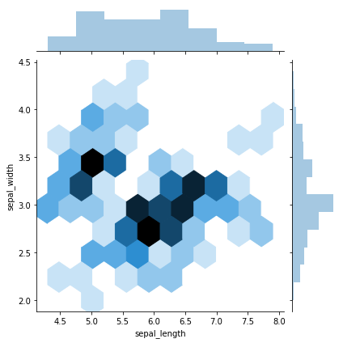

```python
# insert your code here
sns.jointplot(x='sepal_length',y='sepal_width',data=df, kind='hex')
```

With more abstract representation and larger pixels. looks nice.

Now, take a look at what happens when you set `kind="kde"`

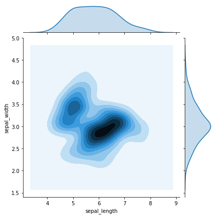

```python
sns.jointplot(x='sepal_length',y='sepal_width',data=df,kind="kde")
```

Finally, you may want to look at all the numeric variables in your dataset. Use `pairplot` to do this:

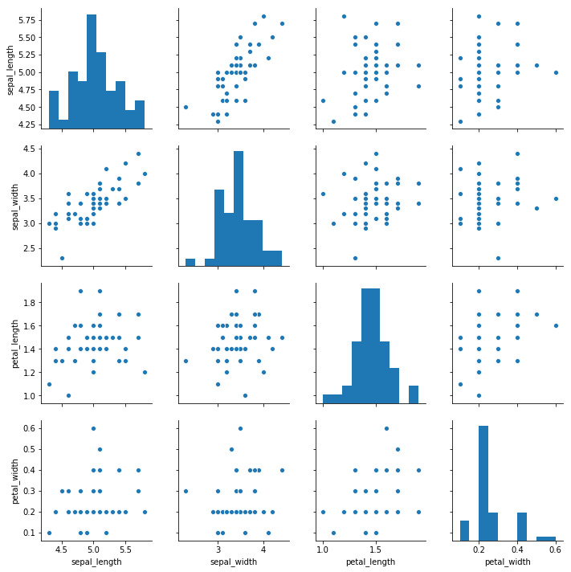

```python
sns.pairplot(df.query("species == 'setosa'"))
```

We can get fancier by using a different column to set the color (or "hue"):

Try running the following code:

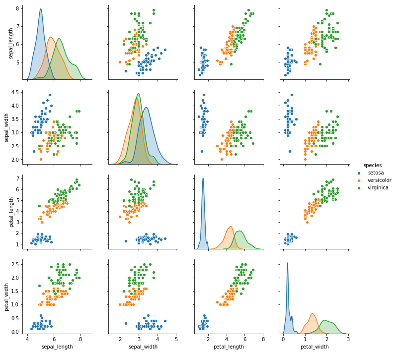

```python
sns.pairplot(df,hue="species")
```

Now let's introduce some correlations. We're not going to spend time on learning about the theory behind correlation, as you've done that in the statistics prerequisite for this course. Instead, we're going to jump right in and annotate a graph with a lot of statistical information:

```python
from scipy import stats
```

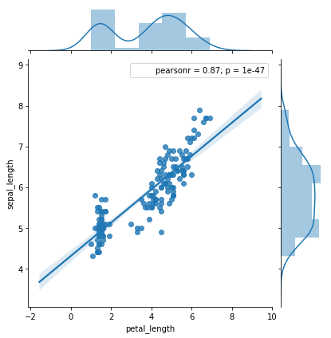

```python
# ignore the warning about deprecated annotation
g = sns.JointGrid(data=df,x='petal_length',y='sepal_length')
g = g.plot(sns.regplot, sns.distplot)
g = g.annotate(stats.pearsonr)
```

Think about what the different components mean. We'll return to using this in the next section on Wine Quality.

## Part 2: Wine quality

[figure not shown]

https://www.kaggle.com/uciml/red-wine-quality-cortez-et-al-2009/home

```python
import pandas as pd
import seaborn as sns
import numpy as np
```

```python
wine = pd.read_csv('data/winequality-red.csv')
wine.head()
```

|  | fixed acidity | volatile acidity | citric acid | residual sugar | chlorides | free sulfur dioxide | total sulfur dioxide | density | pH | sulphates | alcohol | quality |
| --- | --- | --- | --- | --- | --- | --- | --- | --- | --- | --- | --- | --- |
| 0 | 7.4 | 0.70 | 0.00 | 1.9 | 0.076 | 11.0 | 34.0 | 0.9978 | 3.51 | 0.56 | 9.4 | 5 |
| 1 | 7.8 | 0.88 | 0.00 | 2.6 | 0.098 | 25.0 | 67.0 | 0.9968 | 3.20 | 0.68 | 9.8 | 5 |
| 2 | 7.8 | 0.76 | 0.04 | 2.3 | 0.092 | 15.0 | 54.0 | 0.9970 | 3.26 | 0.65 | 9.8 | 5 |
| 3 | 11.2 | 0.28 | 0.56 | 1.9 | 0.075 | 17.0 | 60.0 | 0.9980 | 3.16 | 0.58 | 9.8 | 6 |
| 4 | 7.4 | 0.70 | 0.00 | 1.9 | 0.076 | 11.0 | 34.0 | 0.9978 | 3.51 | 0.56 | 9.4 | 5 |

```python
wine['isgood'] = np.where(wine['quality'] > 5, 'good','bad')
```

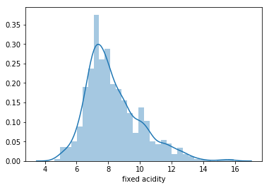

```python
# This will yield a warning if you're using python >= 3.7 and scipy < 1.2
#   For now, I suggest ignoring the warning
#   For a more detailed explanation, please see https://stackoverflow.com/questions/52594235/futurewarning-using-a-non-tuple-sequence-for-multidimensional-indexing-is-depre

sns.distplot(wine['fixed acidity'])
```

```python
wine
```

|  | fixed acidity | volatile acidity | citric acid | residual sugar | chlorides | free sulfur dioxide | total sulfur dioxide | density | pH | sulphates | alcohol | quality | isgood |
| --- | --- | --- | --- | --- | --- | --- | --- | --- | --- | --- | --- | --- | --- |
| 0 | 7.4 | 0.700 | 0.00 | 1.9 | 0.076 | 11.0 | 34.0 | 0.99780 | 3.51 | 0.56 | 9.4 | 5 | bad |
| 1 | 7.8 | 0.880 | 0.00 | 2.6 | 0.098 | 25.0 | 67.0 | 0.99680 | 3.20 | 0.68 | 9.8 | 5 | bad |
| 2 | 7.8 | 0.760 | 0.04 | 2.3 | 0.092 | 15.0 | 54.0 | 0.99700 | 3.26 | 0.65 | 9.8 | 5 | bad |
| 3 | 11.2 | 0.280 | 0.56 | 1.9 | 0.075 | 17.0 | 60.0 | 0.99800 | 3.16 | 0.58 | 9.8 | 6 | good |
| 4 | 7.4 | 0.700 | 0.00 | 1.9 | 0.076 | 11.0 | 34.0 | 0.99780 | 3.51 | 0.56 | 9.4 | 5 | bad |
| 5 | 7.4 | 0.660 | 0.00 | 1.8 | 0.075 | 13.0 | 40.0 | 0.99780 | 3.51 | 0.56 | 9.4 | 5 | bad |
| 6 | 7.9 | 0.600 | 0.06 | 1.6 | 0.069 | 15.0 | 59.0 | 0.99640 | 3.30 | 0.46 | 9.4 | 5 | bad |
| 7 | 7.3 | 0.650 | 0.00 | 1.2 | 0.065 | 15.0 | 21.0 | 0.99460 | 3.39 | 0.47 | 10.0 | 7 | good |
| 8 | 7.8 | 0.580 | 0.02 | 2.0 | 0.073 | 9.0 | 18.0 | 0.99680 | 3.36 | 0.57 | 9.5 | 7 | good |
| 9 | 7.5 | 0.500 | 0.36 | 6.1 | 0.071 | 17.0 | 102.0 | 0.99780 | 3.35 | 0.80 | 10.5 | 5 | bad |
| 10 | 6.7 | 0.580 | 0.08 | 1.8 | 0.097 | 15.0 | 65.0 | 0.99590 | 3.28 | 0.54 | 9.2 | 5 | bad |
| 11 | 7.5 | 0.500 | 0.36 | 6.1 | 0.071 | 17.0 | 102.0 | 0.99780 | 3.35 | 0.80 | 10.5 | 5 | bad |
| 12 | 5.6 | 0.615 | 0.00 | 1.6 | 0.089 | 16.0 | 59.0 | 0.99430 | 3.58 | 0.52 | 9.9 | 5 | bad |
| 13 | 7.8 | 0.610 | 0.29 | 1.6 | 0.114 | 9.0 | 29.0 | 0.99740 | 3.26 | 1.56 | 9.1 | 5 | bad |
| 14 | 8.9 | 0.620 | 0.18 | 3.8 | 0.176 | 52.0 | 145.0 | 0.99860 | 3.16 | 0.88 | 9.2 | 5 | bad |
| 15 | 8.9 | 0.620 | 0.19 | 3.9 | 0.170 | 51.0 | 148.0 | 0.99860 | 3.17 | 0.93 | 9.2 | 5 | bad |
| 16 | 8.5 | 0.280 | 0.56 | 1.8 | 0.092 | 35.0 | 103.0 | 0.99690 | 3.30 | 0.75 | 10.5 | 7 | good |
| 17 | 8.1 | 0.560 | 0.28 | 1.7 | 0.368 | 16.0 | 56.0 | 0.99680 | 3.11 | 1.28 | 9.3 | 5 | bad |
| 18 | 7.4 | 0.590 | 0.08 | 4.4 | 0.086 | 6.0 | 29.0 | 0.99740 | 3.38 | 0.50 | 9.0 | 4 | bad |
| 19 | 7.9 | 0.320 | 0.51 | 1.8 | 0.341 | 17.0 | 56.0 | 0.99690 | 3.04 | 1.08 | 9.2 | 6 | good |
| 20 | 8.9 | 0.220 | 0.48 | 1.8 | 0.077 | 29.0 | 60.0 | 0.99680 | 3.39 | 0.53 | 9.4 | 6 | good |
| 21 | 7.6 | 0.390 | 0.31 | 2.3 | 0.082 | 23.0 | 71.0 | 0.99820 | 3.52 | 0.65 | 9.7 | 5 | bad |
| 22 | 7.9 | 0.430 | 0.21 | 1.6 | 0.106 | 10.0 | 37.0 | 0.99660 | 3.17 | 0.91 | 9.5 | 5 | bad |
| 23 | 8.5 | 0.490 | 0.11 | 2.3 | 0.084 | 9.0 | 67.0 | 0.99680 | 3.17 | 0.53 | 9.4 | 5 | bad |
| 24 | 6.9 | 0.400 | 0.14 | 2.4 | 0.085 | 21.0 | 40.0 | 0.99680 | 3.43 | 0.63 | 9.7 | 6 | good |
| 25 | 6.3 | 0.390 | 0.16 | 1.4 | 0.080 | 11.0 | 23.0 | 0.99550 | 3.34 | 0.56 | 9.3 | 5 | bad |
| 26 | 7.6 | 0.410 | 0.24 | 1.8 | 0.080 | 4.0 | 11.0 | 0.99620 | 3.28 | 0.59 | 9.5 | 5 | bad |
| 27 | 7.9 | 0.430 | 0.21 | 1.6 | 0.106 | 10.0 | 37.0 | 0.99660 | 3.17 | 0.91 | 9.5 | 5 | bad |
| 28 | 7.1 | 0.710 | 0.00 | 1.9 | 0.080 | 14.0 | 35.0 | 0.99720 | 3.47 | 0.55 | 9.4 | 5 | bad |
| 29 | 7.8 | 0.645 | 0.00 | 2.0 | 0.082 | 8.0 | 16.0 | 0.99640 | 3.38 | 0.59 | 9.8 | 6 | good |
| ... | ... | ... | ... | ... | ... | ... | ... | ... | ... | ... | ... | ... | ... |
| 1569 | 6.2 | 0.510 | 0.14 | 1.9 | 0.056 | 15.0 | 34.0 | 0.99396 | 3.48 | 0.57 | 11.5 | 6 | good |
| 1570 | 6.4 | 0.360 | 0.53 | 2.2 | 0.230 | 19.0 | 35.0 | 0.99340 | 3.37 | 0.93 | 12.4 | 6 | good |
| 1571 | 6.4 | 0.380 | 0.14 | 2.2 | 0.038 | 15.0 | 25.0 | 0.99514 | 3.44 | 0.65 | 11.1 | 6 | good |
| 1572 | 7.3 | 0.690 | 0.32 | 2.2 | 0.069 | 35.0 | 104.0 | 0.99632 | 3.33 | 0.51 | 9.5 | 5 | bad |
| 1573 | 6.0 | 0.580 | 0.20 | 2.4 | 0.075 | 15.0 | 50.0 | 0.99467 | 3.58 | 0.67 | 12.5 | 6 | good |
| 1574 | 5.6 | 0.310 | 0.78 | 13.9 | 0.074 | 23.0 | 92.0 | 0.99677 | 3.39 | 0.48 | 10.5 | 6 | good |
| 1575 | 7.5 | 0.520 | 0.40 | 2.2 | 0.060 | 12.0 | 20.0 | 0.99474 | 3.26 | 0.64 | 11.8 | 6 | good |
| 1576 | 8.0 | 0.300 | 0.63 | 1.6 | 0.081 | 16.0 | 29.0 | 0.99588 | 3.30 | 0.78 | 10.8 | 6 | good |
| 1577 | 6.2 | 0.700 | 0.15 | 5.1 | 0.076 | 13.0 | 27.0 | 0.99622 | 3.54 | 0.60 | 11.9 | 6 | good |
| 1578 | 6.8 | 0.670 | 0.15 | 1.8 | 0.118 | 13.0 | 20.0 | 0.99540 | 3.42 | 0.67 | 11.3 | 6 | good |
| 1579 | 6.2 | 0.560 | 0.09 | 1.7 | 0.053 | 24.0 | 32.0 | 0.99402 | 3.54 | 0.60 | 11.3 | 5 | bad |
| 1580 | 7.4 | 0.350 | 0.33 | 2.4 | 0.068 | 9.0 | 26.0 | 0.99470 | 3.36 | 0.60 | 11.9 | 6 | good |
| 1581 | 6.2 | 0.560 | 0.09 | 1.7 | 0.053 | 24.0 | 32.0 | 0.99402 | 3.54 | 0.60 | 11.3 | 5 | bad |
| 1582 | 6.1 | 0.715 | 0.10 | 2.6 | 0.053 | 13.0 | 27.0 | 0.99362 | 3.57 | 0.50 | 11.9 | 5 | bad |
| 1583 | 6.2 | 0.460 | 0.29 | 2.1 | 0.074 | 32.0 | 98.0 | 0.99578 | 3.33 | 0.62 | 9.8 | 5 | bad |
| 1584 | 6.7 | 0.320 | 0.44 | 2.4 | 0.061 | 24.0 | 34.0 | 0.99484 | 3.29 | 0.80 | 11.6 | 7 | good |
| 1585 | 7.2 | 0.390 | 0.44 | 2.6 | 0.066 | 22.0 | 48.0 | 0.99494 | 3.30 | 0.84 | 11.5 | 6 | good |
| 1586 | 7.5 | 0.310 | 0.41 | 2.4 | 0.065 | 34.0 | 60.0 | 0.99492 | 3.34 | 0.85 | 11.4 | 6 | good |
| 1587 | 5.8 | 0.610 | 0.11 | 1.8 | 0.066 | 18.0 | 28.0 | 0.99483 | 3.55 | 0.66 | 10.9 | 6 | good |
| 1588 | 7.2 | 0.660 | 0.33 | 2.5 | 0.068 | 34.0 | 102.0 | 0.99414 | 3.27 | 0.78 | 12.8 | 6 | good |
| 1589 | 6.6 | 0.725 | 0.20 | 7.8 | 0.073 | 29.0 | 79.0 | 0.99770 | 3.29 | 0.54 | 9.2 | 5 | bad |
| 1590 | 6.3 | 0.550 | 0.15 | 1.8 | 0.077 | 26.0 | 35.0 | 0.99314 | 3.32 | 0.82 | 11.6 | 6 | good |
| 1591 | 5.4 | 0.740 | 0.09 | 1.7 | 0.089 | 16.0 | 26.0 | 0.99402 | 3.67 | 0.56 | 11.6 | 6 | good |
| 1592 | 6.3 | 0.510 | 0.13 | 2.3 | 0.076 | 29.0 | 40.0 | 0.99574 | 3.42 | 0.75 | 11.0 | 6 | good |
| 1593 | 6.8 | 0.620 | 0.08 | 1.9 | 0.068 | 28.0 | 38.0 | 0.99651 | 3.42 | 0.82 | 9.5 | 6 | good |
| 1594 | 6.2 | 0.600 | 0.08 | 2.0 | 0.090 | 32.0 | 44.0 | 0.99490 | 3.45 | 0.58 | 10.5 | 5 | bad |
| 1595 | 5.9 | 0.550 | 0.10 | 2.2 | 0.062 | 39.0 | 51.0 | 0.99512 | 3.52 | 0.76 | 11.2 | 6 | good |
| 1596 | 6.3 | 0.510 | 0.13 | 2.3 | 0.076 | 29.0 | 40.0 | 0.99574 | 3.42 | 0.75 | 11.0 | 6 | good |
| 1597 | 5.9 | 0.645 | 0.12 | 2.0 | 0.075 | 32.0 | 44.0 | 0.99547 | 3.57 | 0.71 | 10.2 | 5 | bad |
| 1598 | 6.0 | 0.310 | 0.47 | 3.6 | 0.067 | 18.0 | 42.0 | 0.99549 | 3.39 | 0.66 | 11.0 | 6 | good |

1599 rows × 13 columns

## Q5: Create a pairplot for the wine dataset that plots 'good' and 'bad' wines in different hues. In a couple of sentences, describe interesting relationships shown by the visualization.

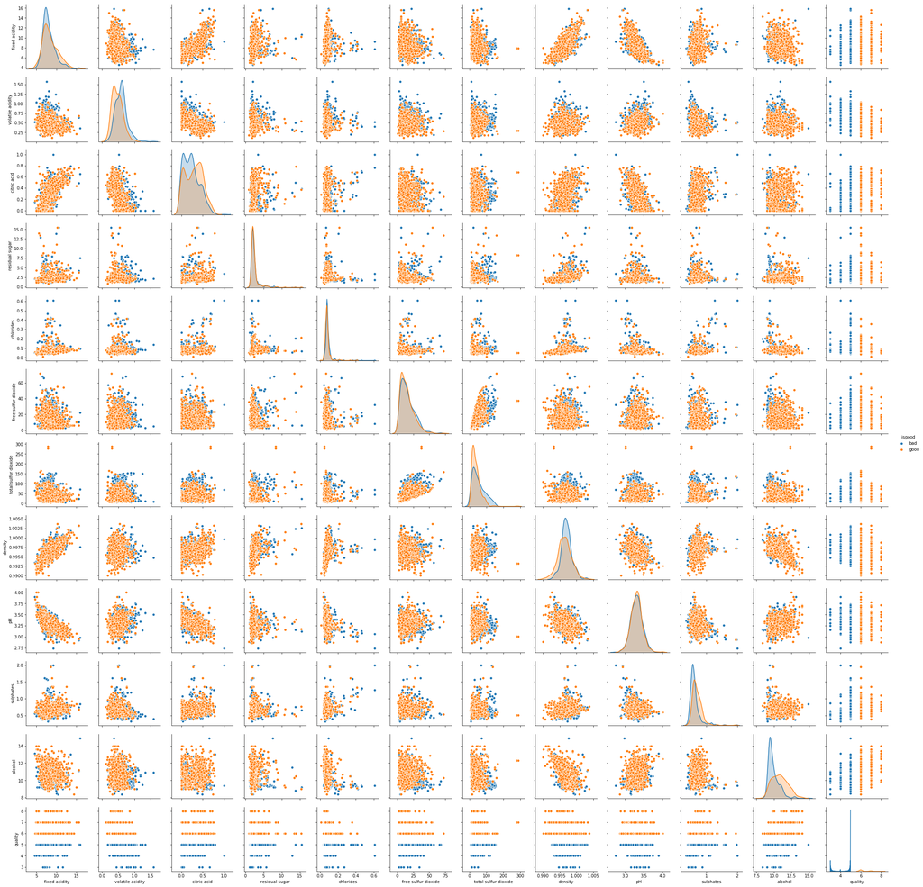

```python
# insert your code here
sns.pairplot(wine,hue="isgood")
```

## T-test

A t-test is a simple statistical model that's commonly used to test whether the means of two different distributions are the same. scipy.stats gives us a handy interface for this:

```python
goodwines = wine.query('isgood == "good"')
badwines = wine.query('isgood == "bad"')
```

```python
stats.ttest_ind(wine[wine.isgood == 'good']['fixed acidity'],wine[wine.isgood == 'bad']['fixed acidity'])
```

```
Ttest_indResult(statistic=3.817471367791021, pvalue=0.00013997664808333373)
```

## Q6: Using the JointGrid approach we used above look at the relationship between sulphates and chlorides. What patterns do you see?

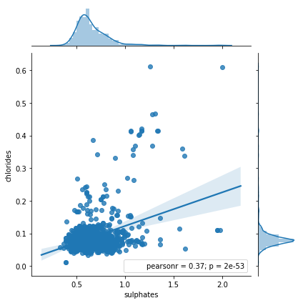

```python
g = sns.JointGrid(data=wine, x='sulphates', y='chlorides')
g = g.plot(sns.regplot, sns.distplot)
g = g.annotate(stats.pearsonr)
```

The sulphates and chlorides seemingly both have normal distribution, but they barely have a linear relationship because the plot shows high randomness, but according to the pearsonr value (0.37 > 0), they have a weak positive relationship.

## Ordinary Least Squares (OLS) Regression

We can get a lot more detail about the regression model by using statsmodels

```python
import statsmodels.api as sm
import statsmodels.formula.api as smf
```

statsmodels.formula.api allows you to use R-Style formulas: y ~ x1 + x2 + x3 + ...

1. y represents the outcome/dependent variable
2. x1, x2, x3, etc represent explanatory/independent variables

```python
model1 = smf.ols('chlorides ~ sulphates', data=wine).fit()
model1.summary()
```

OLS Regression Results

| Dep. Variable: | chlorides | R-squared: | 0.138 |
| --- | --- | --- | --- |
| Model: | OLS | Adj. R-squared: | 0.137 |
| Method: | Least Squares | F-statistic: | 255.3 |
| Date: | Mon, 18 Feb 2019 | Prob (F-statistic): | 1.99e-53 |
| Time: | 19:10:13 | Log-Likelihood: | 2737.1 |
| No. Observations: | 1599 | AIC: | -5470. |
| Df Residuals: | 1597 | BIC: | -5459. |
| Df Model: | 1 |  |  |
| Covariance Type: | nonrobust |  |  |

|  | coef | std err | t | P>\|t\| | [0.025 | 0.975] |
| --- | --- | --- | --- | --- | --- | --- |
| Intercept | 0.0196 | 0.004 | 4.475 | 0.000 | 0.011 | 0.028 |
| sulphates | 0.1031 | 0.006 | 15.978 | 0.000 | 0.090 | 0.116 |

| Omnibus: | 1419.606 | Durbin-Watson: | 1.779 |
| --- | --- | --- | --- |
| Prob(Omnibus): | 0.000 | Jarque-Bera (JB): | 51655.663 |
| Skew: | 4.079 | Prob(JB): | 0.00 |
| Kurtosis: | 29.622 | Cond. No. | 8.51 |

Warnings:  
[1] Standard Errors assume that the covariance matrix of the errors is correctly specified.

### Interesting things happen when we use OLS to do an ANOVA (look closely at the model):

```python
model2 = smf.ols('chlorides ~ C(isgood)', data=wine).fit()
model2.summary()
```

OLS Regression Results

| Dep. Variable: | chlorides | R-squared: | 0.012 |
| --- | --- | --- | --- |
| Model: | OLS | Adj. R-squared: | 0.011 |
| Method: | Least Squares | F-statistic: | 19.38 |
| Date: | Mon, 18 Feb 2019 | Prob (F-statistic): | 1.14e-05 |
| Time: | 19:10:49 | Log-Likelihood: | 2628.2 |
| No. Observations: | 1599 | AIC: | -5252. |
| Df Residuals: | 1597 | BIC: | -5242. |
| Df Model: | 1 |  |  |
| Covariance Type: | nonrobust |  |  |

|  | coef | std err | t | P>\|t\| | [0.025 | 0.975] |
| --- | --- | --- | --- | --- | --- | --- |
| Intercept | 0.0930 | 0.002 | 54.200 | 0.000 | 0.090 | 0.096 |
| C(isgood)[T.good] | -0.0103 | 0.002 | -4.402 | 0.000 | -0.015 | -0.006 |

| Omnibus: | 1776.944 | Durbin-Watson: | 1.871 |
| --- | --- | --- | --- |
| Prob(Omnibus): | 0.000 | Jarque-Bera (JB): | 121109.713 |
| Skew: | 5.649 | Prob(JB): | 0.00 |
| Kurtosis: | 44.111 | Cond. No. | 2.71 |

Warnings:  
[1] Standard Errors assume that the covariance matrix of the errors is correctly specified.

```python
aov_table = sm.stats.anova_lm(model2, typ=2)
print(aov_table)
```

```
             sum_sq      df          F    PR(>F)
C(isgood)  0.042438     1.0  19.378659  0.000011
Residual   3.497360  1597.0        NaN       NaN
```

### We might want to experiment with the original `quality` variable, either in a regression model:

```python
model3 = smf.ols('chlorides ~ quality', data=wine).fit()
model3.summary()
```

OLS Regression Results

| Dep. Variable: | chlorides | R-squared: | 0.017 |
| --- | --- | --- | --- |
| Model: | OLS | Adj. R-squared: | 0.016 |
| Method: | Least Squares | F-statistic: | 26.99 |
| Date: | Mon, 18 Feb 2019 | Prob (F-statistic): | 2.31e-07 |
| Time: | 19:16:41 | Log-Likelihood: | 2631.9 |
| No. Observations: | 1599 | AIC: | -5260. |
| Df Residuals: | 1597 | BIC: | -5249. |
| Df Model: | 1 |  |  |
| Covariance Type: | nonrobust |  |  |

|  | coef | std err | t | P>\|t\| | [0.025 | 0.975] |
| --- | --- | --- | --- | --- | --- | --- |
| Intercept | 0.1298 | 0.008 | 15.765 | 0.000 | 0.114 | 0.146 |
| quality | -0.0075 | 0.001 | -5.195 | 0.000 | -0.010 | -0.005 |

| Omnibus: | 1776.366 | Durbin-Watson: | 1.877 |
| --- | --- | --- | --- |
| Prob(Omnibus): | 0.000 | Jarque-Bera (JB): | 120907.596 |
| Skew: | 5.646 | Prob(JB): | 0.00 |
| Kurtosis: | 44.076 | Cond. No. | 41.4 |

Warnings:  
[1] Standard Errors assume that the covariance matrix of the errors is correctly specified.

### or in an ANOVA (again, look closely at the model):

```python
model4 = smf.ols('chlorides ~ C(quality)', data=wine).fit()
model4.summary()
# C(quality) tnrns quality to categorical model
```

OLS Regression Results

| Dep. Variable: | chlorides | R-squared: | 0.019 |
| --- | --- | --- | --- |
| Model: | OLS | Adj. R-squared: | 0.016 |
| Method: | Least Squares | F-statistic: | 6.036 |
| Date: | Mon, 18 Feb 2019 | Prob (F-statistic): | 1.53e-05 |
| Time: | 19:17:15 | Log-Likelihood: | 2633.5 |
| No. Observations: | 1599 | AIC: | -5255. |
| Df Residuals: | 1593 | BIC: | -5223. |
| Df Model: | 5 |  |  |
| Covariance Type: | nonrobust |  |  |

|  | coef | std err | t | P>\|t\| | [0.025 | 0.975] |
| --- | --- | --- | --- | --- | --- | --- |
| Intercept | 0.1225 | 0.015 | 8.295 | 0.000 | 0.094 | 0.151 |
| C(quality)[T.4] | -0.0318 | 0.016 | -1.976 | 0.048 | -0.063 | -0.000 |
| C(quality)[T.5] | -0.0298 | 0.015 | -2.001 | 0.046 | -0.059 | -0.001 |
| C(quality)[T.6] | -0.0375 | 0.015 | -2.523 | 0.012 | -0.067 | -0.008 |
| C(quality)[T.7] | -0.0459 | 0.015 | -3.034 | 0.002 | -0.076 | -0.016 |
| C(quality)[T.8] | -0.0541 | 0.018 | -2.935 | 0.003 | -0.090 | -0.018 |

| Omnibus: | 1784.926 | Durbin-Watson: | 1.874 |
| --- | --- | --- | --- |
| Prob(Omnibus): | 0.000 | Jarque-Bera (JB): | 124552.412 |
| Skew: | 5.683 | Prob(JB): | 0.00 |
| Kurtosis: | 44.717 | Cond. No. | 36.7 |

Warnings:  
[1] Standard Errors assume that the covariance matrix of the errors is correctly specified.

```python
aov_table = sm.stats.anova_lm(model4, typ=2)
print(aov_table)
```

```
              sum_sq      df         F    PR(>F)
C(quality)  0.065812     5.0  6.035639  0.000015
Residual    3.473986  1593.0       NaN       NaN
```

## Q7: Use OLS to perform either a regression or an ANOVA on a variable (other than chlorides) and interpret your results.

```python
model7 = smf.ols('density ~ C(quality)', data=wine).fit()
model7.summary()
```

OLS Regression Results

| Dep. Variable: | density | R-squared: | 0.040 |
| --- | --- | --- | --- |
| Model: | OLS | Adj. R-squared: | 0.037 |
| Method: | Least Squares | F-statistic: | 13.40 |
| Date: | Mon, 18 Feb 2019 | Prob (F-statistic): | 8.12e-13 |
| Time: | 19:24:10 | Log-Likelihood: | 7794.4 |
| No. Observations: | 1599 | AIC: | -1.558e+04 |
| Df Residuals: | 1593 | BIC: | -1.554e+04 |
| Df Model: | 5 |  |  |
| Covariance Type: | nonrobust |  |  |

|  | coef | std err | t | P>\|t\| | [0.025 | 0.975] |
| --- | --- | --- | --- | --- | --- | --- |
| Intercept | 0.9975 | 0.001 | 1703.381 | 0.000 | 0.996 | 0.999 |
| C(quality)[T.4] | -0.0009 | 0.001 | -1.443 | 0.149 | -0.002 | 0.000 |
| C(quality)[T.5] | -0.0004 | 0.001 | -0.611 | 0.541 | -0.002 | 0.001 |
| C(quality)[T.6] | -0.0008 | 0.001 | -1.439 | 0.150 | -0.002 | 0.000 |
| C(quality)[T.7] | -0.0014 | 0.001 | -2.266 | 0.024 | -0.003 | -0.000 |
| C(quality)[T.8] | -0.0023 | 0.001 | -3.083 | 0.002 | -0.004 | -0.001 |

| Omnibus: | 43.952 | Durbin-Watson: | 1.263 |
| --- | --- | --- | --- |
| Prob(Omnibus): | 0.000 | Jarque-Bera (JB): | 74.559 |
| Skew: | 0.225 | Prob(JB): | 6.45e-17 |
| Kurtosis: | 3.958 | Cond. No. | 36.7 |

Warnings:  
[1] Standard Errors assume that the covariance matrix of the errors is correctly specified.

```python
aov_table = sm.stats.anova_lm(model7, typ=2)
print(aov_table)
```

```
              sum_sq      df          F        PR(>F)
C(quality)  0.000230     5.0  13.396357  8.124395e-13
Residual    0.005462  1593.0        NaN           NaN
```

## Part 3: Airplane Crashes and Fatalities

The next dataset we are going to look at is the full history of airplane crashes throughout the world, from 1908-2009. It's taken from:

https://opendata.socrata.com/Government/Airplane-Crashes-and-Fatalities-Since-1908/q2te-8cvq

```python
import pandas as pd
import seaborn as sns
```

We've provided the CSV file for this lab so you can go ahead and load it in the usual way:

```python
crashes = pd.read_csv('data/Airplane_Crashes_and_Fatalities_Since_1908.csv')
```

As always, you should take a look at the data to get a sense of what it's like:

```python
crashes.head()
```

|  | Date | Time | Location | Operator | Flight # | Route | Type | Registration | cn/In | Aboard | Fatalities | Ground | Summary |
| --- | --- | --- | --- | --- | --- | --- | --- | --- | --- | --- | --- | --- | --- |
| 0 | 09/17/1908 | 17:18 | Fort Myer, Virginia | Military - U.S. Army | NaN | Demonstration | Wright Flyer III | NaN | 1 | 2.0 | 1.0 | 0.0 | During a demonstration flight, a U.S. Army fly... |
| 1 | 07/12/1912 | 06:30 | AtlantiCity, New Jersey | Military - U.S. Navy | NaN | Test flight | Dirigible | NaN | NaN | 5.0 | 5.0 | 0.0 | First U.S. dirigible Akron exploded just offsh... |
| 2 | 08/06/1913 | NaN | Victoria, British Columbia, Canada | Private | - | NaN | Curtiss seaplane | NaN | NaN | 1.0 | 1.0 | 0.0 | The first fatal airplane accident in Canada oc... |
| 3 | 09/09/1913 | 18:30 | Over the North Sea | Military - German Navy | NaN | NaN | Zeppelin L-1 (airship) | NaN | NaN | 20.0 | 14.0 | 0.0 | The airship flew into a thunderstorm and encou... |
| 4 | 10/17/1913 | 10:30 | Near Johannisthal, Germany | Military - German Navy | NaN | NaN | Zeppelin L-2 (airship) | NaN | NaN | 30.0 | 30.0 | 0.0 | Hydrogen gas which was being vented was sucked... |

As we mentioned in an earlier class, pandas is really good at helping us deal with dates. The 'Date' column in the dataframe contains strings that look like dates. We can use the `pandas.to_datetime()` function to convert the strings to an internal datetime object (see https://pandas.pydata.org/pandas-docs/stable/generated/pandas.to_datetime.html for more details):

```python
crashes['Date'] = pd.to_datetime(crashes['Date'])
```

And let's look at the dataframe again. See any difference?

```python
crashes.head()
```

|  | Date | Time | Location | Operator | Flight # | Route | Type | Registration | cn/In | Aboard | Fatalities | Ground | Summary |
| --- | --- | --- | --- | --- | --- | --- | --- | --- | --- | --- | --- | --- | --- |
| 0 | 1908-09-17 | 17:18 | Fort Myer, Virginia | Military - U.S. Army | NaN | Demonstration | Wright Flyer III | NaN | 1 | 2.0 | 1.0 | 0.0 | During a demonstration flight, a U.S. Army fly... |
| 1 | 1912-07-12 | 06:30 | AtlantiCity, New Jersey | Military - U.S. Navy | NaN | Test flight | Dirigible | NaN | NaN | 5.0 | 5.0 | 0.0 | First U.S. dirigible Akron exploded just offsh... |
| 2 | 1913-08-06 | NaN | Victoria, British Columbia, Canada | Private | - | NaN | Curtiss seaplane | NaN | NaN | 1.0 | 1.0 | 0.0 | The first fatal airplane accident in Canada oc... |
| 3 | 1913-09-09 | 18:30 | Over the North Sea | Military - German Navy | NaN | NaN | Zeppelin L-1 (airship) | NaN | NaN | 20.0 | 14.0 | 0.0 | The airship flew into a thunderstorm and encou... |
| 4 | 1913-10-17 | 10:30 | Near Johannisthal, Germany | Military - German Navy | NaN | NaN | Zeppelin L-2 (airship) | NaN | NaN | 30.0 | 30.0 | 0.0 | Hydrogen gas which was being vented was sucked... |

The pandas datetime object makes it easy to extract interesting parts of the date or time. In our case, we're interested in extracting the year, so we can do that with the following code:

```python
crashes['year'] = crashes['Date'].dt.year
```

And, as always, let's look at what we got:

```python
crashes.year.head()
```

```
0    1908
1    1912
2    1913
3    1913
4    1913
Name: year, dtype: int64
```

As part of the final exercise in this class, let's create a visualization of the number of Fatalities per year:

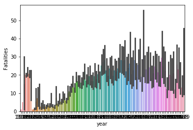

```python
sns.barplot('year','Fatalities',data=crashes)
```

That doesn't look great, does it?

```python
crashes['decade'] = crashes['Date'].dt.decade
```

[output not shown]

## Q8: Create a barplot of the number of fatalities per decade and describe the results.

Go ahead and create a new column called 'decade' that represents the decade for each year. Remember that an integer divide (a.k.a. a floor divide) can be done with the // operator.

What's the trend in airplane crash fatalities?

```python
# insert your code here
crashes['decade'] = crashes['year'] // 10 * 10
```

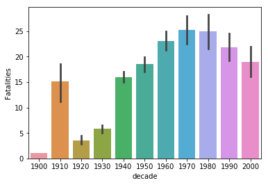

```python
sns.barplot('decade', 'Fatalities', data = crashes)
```

```python
crashes.query('decade == "1910"')
```

|  | Date | Time | Location | Operator | Flight # | Route | Type | Registration | cn/In | Aboard | Fatalities | Ground | Summary | year | decade |
| --- | --- | --- | --- | --- | --- | --- | --- | --- | --- | --- | --- | --- | --- | --- | --- |
| 1 | 1912-07-12 | 06:30 | AtlantiCity, New Jersey | Military - U.S. Navy | NaN | Test flight | Dirigible | NaN | NaN | 5.0 | 5.0 | 0.0 | First U.S. dirigible Akron exploded just offsh... | 1912 | 1910 |
| 2 | 1913-08-06 | NaN | Victoria, British Columbia, Canada | Private | - | NaN | Curtiss seaplane | NaN | NaN | 1.0 | 1.0 | 0.0 | The first fatal airplane accident in Canada oc... | 1913 | 1910 |
| 3 | 1913-09-09 | 18:30 | Over the North Sea | Military - German Navy | NaN | NaN | Zeppelin L-1 (airship) | NaN | NaN | 20.0 | 14.0 | 0.0 | The airship flew into a thunderstorm and encou... | 1913 | 1910 |
| 4 | 1913-10-17 | 10:30 | Near Johannisthal, Germany | Military - German Navy | NaN | NaN | Zeppelin L-2 (airship) | NaN | NaN | 30.0 | 30.0 | 0.0 | Hydrogen gas which was being vented was sucked... | 1913 | 1910 |
| 5 | 1915-03-05 | 01:00 | Tienen, Belgium | Military - German Navy | NaN | NaN | Zeppelin L-8 (airship) | NaN | NaN | 41.0 | 21.0 | 0.0 | Crashed into trees while attempting to land af... | 1915 | 1910 |
| 6 | 1915-09-03 | 15:20 | Off Cuxhaven, Germany | Military - German Navy | NaN | NaN | Zeppelin L-10 (airship) | NaN | NaN | 19.0 | 19.0 | 0.0 | Exploded and burned near Neuwerk Island, when... | 1915 | 1910 |
| 7 | 1916-07-28 | NaN | Near Jambol, Bulgeria | Military - German Army | NaN | NaN | Schutte-Lanz S-L-10 (airship) | NaN | NaN | 20.0 | 20.0 | 0.0 | Crashed near the Black Sea, cause unknown. | 1916 | 1910 |
| 8 | 1916-09-24 | 01:00 | Billericay, England | Military - German Navy | NaN | NaN | Zeppelin L-32 (airship) | NaN | NaN | 22.0 | 22.0 | 0.0 | Shot down by British aircraft crashing in flames. | 1916 | 1910 |
| 9 | 1916-10-01 | 23:45 | Potters Bar, England | Military - German Navy | NaN | NaN | Zeppelin L-31 (airship) | NaN | NaN | 19.0 | 19.0 | 0.0 | Shot down in flames by the British 39th Home D... | 1916 | 1910 |
| 10 | 1916-11-21 | NaN | Mainz, Germany | Military - German Army | NaN | NaN | Super Zeppelin (airship) | NaN | NaN | 28.0 | 27.0 | 0.0 | Crashed in a storm. | 1916 | 1910 |
| 11 | 1916-11-28 | 23:45 | Off West Hartlepool, England | Military - German Navy | NaN | NaN | Zeppelin L-34 (airship) | NaN | NaN | 20.0 | 20.0 | 0.0 | Shot down by British anti-aircraft fire and ai... | 1916 | 1910 |
| 12 | 1917-03-04 | NaN | Near Gent, Belgium | Military - German Army | NaN | NaN | Airship | NaN | NaN | 20.0 | 20.0 | 0.0 | Caught fire and crashed. | 1917 | 1910 |
| 13 | 1917-03-30 | NaN | Off Northern Germany | Military - German Navy | NaN | NaN | Schutte-Lanz S-L-9 (airship) | NaN | NaN | 23.0 | 23.0 | 0.0 | Struck by lightning and crashed into the Balti... | 1917 | 1910 |
| 14 | 1917-05-14 | 05:15 | Near Texel Island, North Sea | Military - German Navy | NaN | NaN | Zeppelin L-22 (airship) | NaN | NaN | 21.0 | 21.0 | 0.0 | Crashed into the sea from an altitude of 3,000... | 1917 | 1910 |
| 15 | 1917-06-14 | 08:45 | Off Vlieland Island, North Sea | Military - German Navy | NaN | NaN | Zeppelin L-43 (airship) | NaN | NaN | 24.0 | 24.0 | 0.0 | Shot down by British aircraft. | 1917 | 1910 |
| 16 | 1917-08-21 | 07:00 | Off western Denmark | Military - German Navy | NaN | NaN | Zeppelin L-23 (airship) | NaN | NaN | 18.0 | 18.0 | 0.0 | Shot down by British aircraft. | 1917 | 1910 |
| 17 | 1917-10-20 | 07:45 | Near Luneville, France | Military - German Navy | NaN | NaN | Zeppelin L-44 (airship) | NaN | NaN | 18.0 | 18.0 | 0.0 | Shot down by French anti-aircraft fire. | 1917 | 1910 |
| 18 | 1918-04-07 | 21:30 | Over the Mediterranean | Military - German Navy | NaN | NaN | Zeppelin L-59 (airship) | NaN | NaN | 23.0 | 23.0 | 0.0 | Exploded and crashed into the sea off the sout... | 1918 | 1910 |
| 19 | 1918-05-10 | NaN | Off Helgoland Island, Germany | Military - German Navy | NaN | NaN | Zeppelin L-70 (airship) | NaN | NaN | 22.0 | 22.0 | 0.0 | Shot down by British aircraft crashing from a ... | 1918 | 1910 |
| 20 | 1918-08-11 | 10:00 | Ameland Island, North Sea | Military - German Navy | NaN | NaN | Zeppelin L-53 (airship) | NaN | NaN | 19.0 | 19.0 | 0.0 | Shot down by british aircraft. | 1918 | 1910 |
| 21 | 1918-12-16 | NaN | Elizabeth, New Jersey | US Aerial Mail Service | NaN | NaN | De Havilland DH-4 | 97 | NaN | 1.0 | 1.0 | 0.0 | NaN | 1918 | 1910 |
| 22 | 1919-05-25 | NaN | Cleveland, Ohio | US Aerial Mail Service | NaN | NaN | De Havilland DH-4 | 61 | NaN | 1.0 | 1.0 | 0.0 | Caught fire in midair. The pilot leaped from t... | 1919 | 1910 |
| 23 | 1919-07-19 | NaN | Dix Run, Pennsylvania | US Aerial Mail Service | NaN | NaN | De Havilland DH-4 | 82 | NaN | 1.0 | 1.0 | 0.0 | NaN | 1919 | 1910 |
| 24 | 1919-10-02 | NaN | Newcastle, England | Aircraft Transport and Travel | NaN | NaN | De Havilland DH-4 | NaN | NaN | 1.0 | 1.0 | 0.0 | NaN | 1919 | 1910 |
| 25 | 1919-10-14 | NaN | Cantonsville, Maryland | US Aerial Mail Service | NaN | NaN | Curtiss R-4LM | 32 | NaN | 1.0 | 1.0 | 0.0 | NaN | 1919 | 1910 |
| 26 | 1919-10-20 | NaN | English Channel | Aircraft Transport and Travel | NaN | NaN | De Havilland DH-4 | G-EAHG | NaN | NaN | NaN | NaN | NaN | 1919 | 1910 |
| 27 | 1919-10-30 | NaN | Long Valley, New Jersey | US Aerial Mail Service | NaN | NaN | De Havilland DH.4 | 77 | NaN | 1.0 | 1.0 | 0.0 | NaN | 1919 | 1910 |

## Q9: (Optional, up to 2 bonus points): Explore some of the options available in Seaborn to control the aesthetics of your plots

Using any of the figures we created in this lab, or any other figures you like, explore manipulating various ways in which you can control the aesthetics of your figures. See https://seaborn.pydata.org/tutorial/aesthetics.html for additional information.

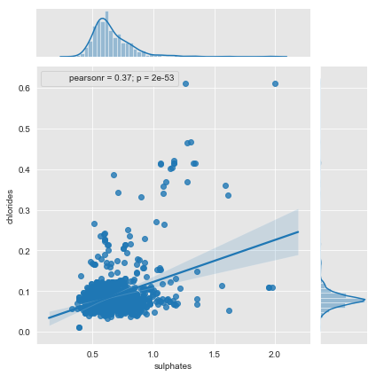

```python
sns.set_style("dark")
sns.set_style("darkgrid", {"axes.facecolor": ".9"})

g = sns.JointGrid(data=wine, x='sulphates', y='chlorides')
g = g.plot(sns.regplot, sns.distplot)
g = g.annotate(stats.pearsonr)
```

Added code to modify the axies style as well as the background color for the joinGrid plot

## Part 4 (FYI): Functional Magnetic Resonance Imagining

**NOTE: The remainder of this notebook requires seaborn 0.9.0 (or newer) to provide the "relplot" capabilities**

[figure not shown]

```python
fmri = sns.load_dataset("fmri")
```

```python
fmri.head()
```

|  | subject | timepoint | event | region | signal |
| --- | --- | --- | --- | --- | --- |
| 0 | s13 | 18 | stim | parietal | -0.017552 |
| 1 | s5 | 14 | stim | parietal | -0.080883 |
| 2 | s12 | 18 | stim | parietal | -0.081033 |
| 3 | s11 | 18 | stim | parietal | -0.046134 |
| 4 | s10 | 18 | stim | parietal | -0.037970 |

```python
fmri.describe()
```

|  | timepoint | signal |
| --- | --- | --- |
| count | 1064.000000 | 1064.000000 |
| mean | 9.000000 | 0.003540 |
| std | 5.479801 | 0.093930 |
| min | 0.000000 | -0.255486 |
| 25% | 4.000000 | -0.046070 |
| 50% | 9.000000 | -0.013653 |
| 75% | 14.000000 | 0.024293 |
| max | 18.000000 | 0.564985 |

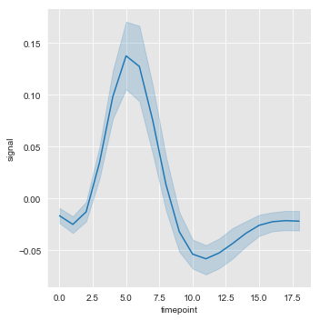

```python
sns.relplot(x="timepoint", y="signal", kind="line", data=fmri);
```

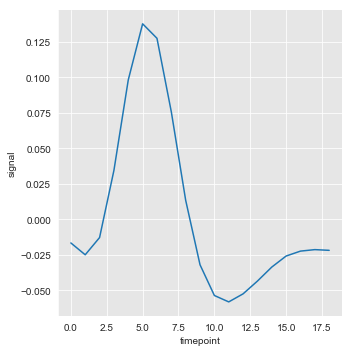

```python
sns.relplot(x="timepoint", y="signal", kind="line", ci=None, data=fmri);
```

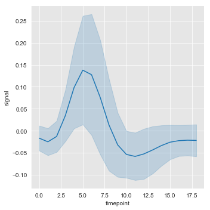

```python
sns.relplot(x="timepoint", y="signal", kind="line", ci="sd",data=fmri);
```

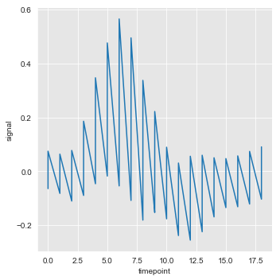

```python
sns.relplot(x="timepoint", y="signal", kind="line", estimator=None, data=fmri);
```

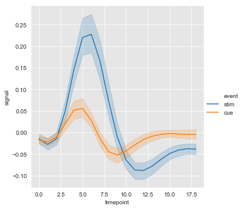

```python
sns.relplot(x = "timepoint", y = "signal", kind = "line", data = fmri, hue = "event");
```

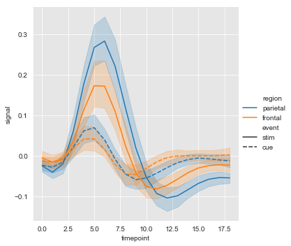

```python
sns.relplot(x="timepoint", y="signal", kind="line", data=fmri, hue="region", style="event");
```